# Beyond Survival: Enhancing numbat Conservation through Data Analysis

Jason A. Dayuha

2024-03-24

# 1. Introduction

This analysis is part of the weekly data analysis program from Tidy Tuesday. It consists of a community of individuals that have a passion for data analytics. Each week, the community analyzes a data project, shares their findings to enhance data analysis skills, and deepen understanding of the week’s subject. The goal of this projects focus is the numbat, an endangered animal native to Australia. This data analysis project is to analyzed the numbat’s population in Australia and to aid in the conservation of its declining species.

# 2. Ask Guided Questions

2.1 Characters and teams:

● Numbat population

2.2 Business task: The numbat data that we are analyzing will answer the following questions:

● Where do you find numbats in Australia?

● Was the distribution more widespread historically? (You may need to exclude zoo reported observations.)

● What time of day do numbat sightings occur?

● Are they more frequent in the summer or winter?

● Are numbats seen more on sunny and warm days than cloudy, wet, cold days?

● Do sightings happen more on week days than weekends?

By answering these questions, we can further understand the numbat population and improve conservation of these unique animals.

# 3. Preparing for Data Exploration

The raw data for this analysis is found in the website [Atlas of Living Australia](https://www.ala.org.au/). However since this project is based from Tidy Tuesday, they have prepared the data for analysis to meet the specific goals in the Tidy Tuesday project. You can find this altered data in the Github Tidy Tuesday link [here](https://github.com/rfordatascience/tidytuesday/blob/master/data/2023/2023-03-07/readme.md).

# 4. Process Data from Raw Data to Clean

This analysis project will be conducted using R programming due to its free, open-source, statistical and graphical analysis capabilities. Please refer to the Appendix regarding the R programming code used to accomplish the following tasks:

4.1 Download the Libraries used to work with this data.

4.2 Download the raw data

### Data Exploration

4.3 Identify Column names

List of Column Names in the numbats Data Frame

| decimalLatitude | dataResourceName | dryandra |
| --- | --- | --- |
| decimalLongitude | year | prcp |
| eventDate | month | tmax |
| scientificName | wday | tmin |
| taxonConceptID | hour |  |
| recordID | day |  |

4.3 Clean up column names for proper formatting

4.5 Check to make sure all numbers are formatted correctly.

4.6 Identify outliers in the raw data.

4.7 Check the unique values of each column:

For the column scientificName, the table below identified two unique entries: Myrmecobius fasciatus rufus and Myrmecobius fasciatus. The term Rufus is a subspecies of the numbat with a more reddish brownish coloration. Additionally, data regarding month, day, day of the week (wday), does contain an extra unique value due to cells with blank entry designated as “NA”.

| Column_Name | Number_of_Unique_Values |
| --- | --- |
| scientificName | 2 |
| taxonConceptID | 2 |
| recordID | 805 |
| dataResourceName | 18 |
| month | 13 |
| wday | 8 |
| week | 47 |
| day | 32 |
| ToD | 69 |

4.8 Identify Missing or NA entry- visualization:

There are a significant portion of data missing in this dataset, as illustrated in the chart below. Approximately 92% of the data related to precipitation (prcp), maximum temperature (tmax), and minimum temperature (tmin) are absent from the 805 rows of data examined. Furthermore, the ‘eventDate’ column is lacking around 31 percent of its data. This absence is substantial because it affects the dataset’s ability to support more detailed time-based analyses.

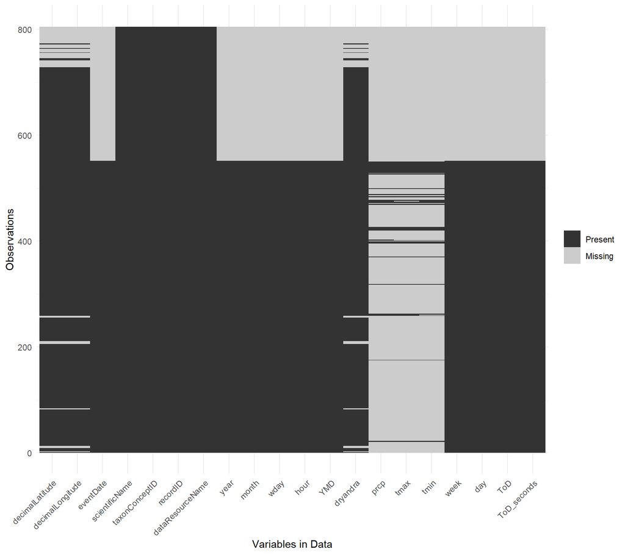

Percentage of Missing Values by Column

|  | Column | MissingPercentage |
| --- | --- | --- |
| decimalLatitude | decimalLatitude | 10.31 |
| decimalLongitude | decimalLongitude | 10.31 |
| eventDate | eventDate | 31.43 |
| scientificName | scientificName | 0.00 |
| taxonConceptID | taxonConceptID | 0.00 |
| recordID | recordID | 0.00 |
| dataResourceName | dataResourceName | 0.00 |
| year | year | 31.43 |
| month | month | 31.43 |
| wday | wday | 31.43 |
| hour | hour | 31.43 |
| YMD | YMD | 31.43 |
| dryandra | dryandra | 10.31 |
| prcp | prcp | 92.67 |
| tmax | tmax | 92.92 |
| tmin | tmin | 92.92 |
| week | week | 31.43 |
| day | day | 31.43 |
| ToD | ToD | 31.43 |
| ToD_seconds | ToD_seconds | 31.43 |

Data Resources by Completeness

| dataResourceName | RowCompleteness |
| --- | --- |
| Earth Guardians Weekly Feed | 100.00 |
| iNaturalist Australia | 97.33 |
| Australian National Wildlife Collection provider for OZCAM | 84.21 |
| Fauna Atlas N.T. | 84.21 |
| NSW BioNet Atlas | 84.21 |
| SA Fauna (BDBSA) | 84.21 |
| Victorian Biodiversity Atlas | 84.21 |
| Encyclopedia of Life Images - Flickr Group | 68.42 |
| ALA species sightings and OzAtlas | 57.89 |
| Australian Museum provider for OZCAM | 44.93 |
| Museums Victoria provider for OZCAM | 40.35 |
| Database of Australasian Vertebrate Occurrences | 31.58 |
| European Molecular Biology Laboratory Australian Mirror | 31.58 |
| Northern Territory Museum and Art Gallery provider for OZCAM | 31.58 |
| Queen Victoria Museum Art Gallery provider for OZCAM | 31.58 |
| Queensland Museum provider for OZCAM | 31.58 |
| Western Australian Museum provider for OZCAM | 28.37 |
| South Australian Museum Adelaide provider for OZCAM | 25.20 |

The table above shows the organization collecting numbat sightings and the completeness of their collected information in regards to the table properties. There are 18 organization that contributed to this numbat sightings only one organization, Earth Guardians Weekly Feed achieved 100% data completeness, following close to 97 %completeness is iNaturalist Australia.

4.9 Find and clean zero values if necessary : No unwanted “zeros” found in hour and prcp

| Column_Name | Number_of_Zero_Values |
| --- | --- |
| decimalLatitude | 0 |
| decimalLongitude | 0 |
| year | 0 |
| hour | 4 |
| prcp | 41 |
| tmax | 0 |
| tmin | 0 |
| ToD_seconds | 0 |

4.10 check for leading and trailing white spaces:

4.11 Check and delete duplicate rows:

# 5. Analysis

### 5.1 Geographic Map - location sighting

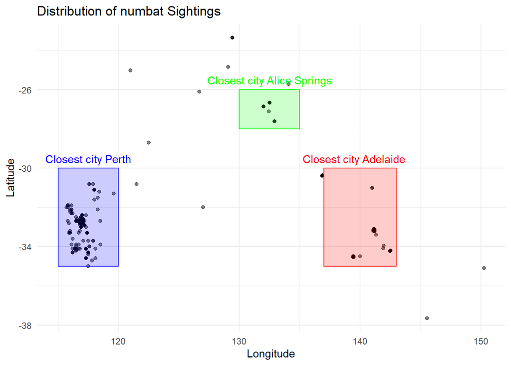

[interactive chart not shown]

[interactive chart not shown]

The geographic map and accompanying table illustrate the distribution of numbat sightings over time. Note that the number of red points represents no time stamp information in this map. No time stamp sighting consist of roughly 31% of the total data as revealed in the data exploration. The map shows most of the SW Australia sighting location cluster do not have time data. Alice Springs is the second major area with a significant number of sightings lacking time information.

Interestingly, the map reveals that sightings of the numbat subspecies, Myrmecobius fasciatus rufus, are confined primarily to Alice Springs, with a few occurrences near Adelaide. A noteworthy detail is the timestamped sighting of the Myrmecobius fasciatus rufus variant near Adelaide goes back to 1856, with subsequent sightings lacking times tamp as well.

SW Australia Sighting Percentages by Year and Scientific Name

| Year | Count | Percentage | Myrmecobius fasciatus Count | Myrmecobius fasciatus rufus Count |
| --- | --- | --- | --- | --- |
| 1906 | 1 | 0.44 | 1 | 0 |
| 1954 | 1 | 0.44 | 1 | 0 |
| 2007 | 2 | 0.88 | 2 | 0 |
| 2014 | 1 | 0.44 | 1 | 0 |
| 2015 | 4 | 1.76 | 4 | 0 |
| 2017 | 3 | 1.32 | 3 | 0 |
| 2019 | 9 | 3.96 | 9 | 0 |
| 2020 | 8 | 3.52 | 8 | 0 |
| 2021 | 15 | 6.61 | 15 | 0 |
| 2022 | 22 | 9.69 | 22 | 0 |
| 2023 | 1 | 0.44 | 1 | 0 |
| NA | 160 | 70.48 | NA | NA |

Focusing on the table above, it highlights the sightings in SW Australia. The table shows that 70% of sightings in that region lack a timestamp. It also indicates an increasing trend in recorded sightings over time, particularly from 2019 onwards, when data collection efforts were enhanced to include timestamps for sightings.

Adelaide Region numbat Sightings Percentages by Year and Scientific Name

| Year | Count | Percentage | Myrmecobius fasciatus Count | Myrmecobius fasciatus rufus Count |
| --- | --- | --- | --- | --- |
| 1856 | 2 | 0.43 | 1 | 1 |
| 2000 | 1 | 0.22 | 1 | 0 |
| 2006 | 1 | 0.22 | 1 | 0 |
| 2008 | 27 | 5.84 | 27 | 0 |
| 2009 | 24 | 5.19 | 24 | 0 |
| 2010 | 8 | 1.73 | 8 | 0 |
| 2011 | 26 | 5.63 | 26 | 0 |
| 2013 | 36 | 7.79 | 36 | 0 |
| 2014 | 103 | 22.29 | 103 | 0 |
| 2015 | 1 | 0.22 | 1 | 0 |
| 2016 | 51 | 11.04 | 51 | 0 |
| 2017 | 53 | 11.47 | 53 | 0 |
| 2018 | 23 | 4.98 | 23 | 0 |
| 2019 | 17 | 3.68 | 17 | 0 |
| 2020 | 42 | 9.09 | 42 | 0 |
| 2021 | 44 | 9.52 | 44 | 0 |
| NA | 3 | 0.65 | NA | NA |

Central Region numbat Sightings by Year and Scientific Name

| Year | scientificName | Count |
| --- | --- | --- |
| NA | Myrmecobius fasciatus rufus | 15 |

In central Australia near Alice Springs, there are 15 sightings recorded with no time stamp information Interesting enough the variant M. fasciatus rufus is predominantly seen in this region.

### 5.2 Heat Map- Time of day, Month

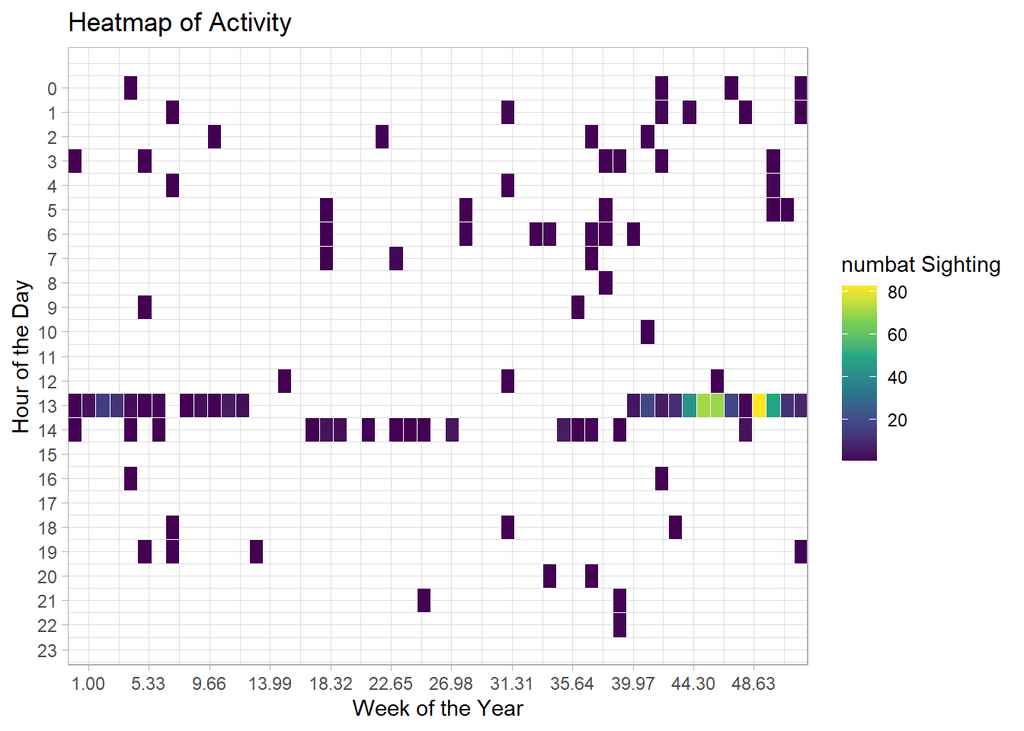

### 5.3 Bar Graph- Time of day

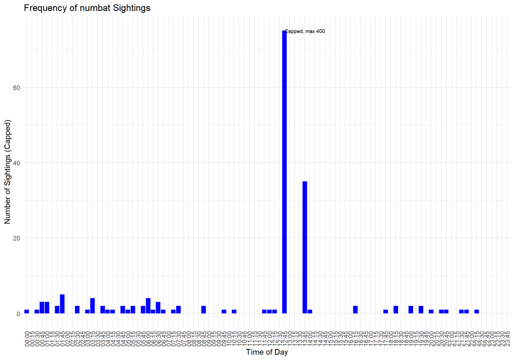

### 5.4 Weather Temperature data

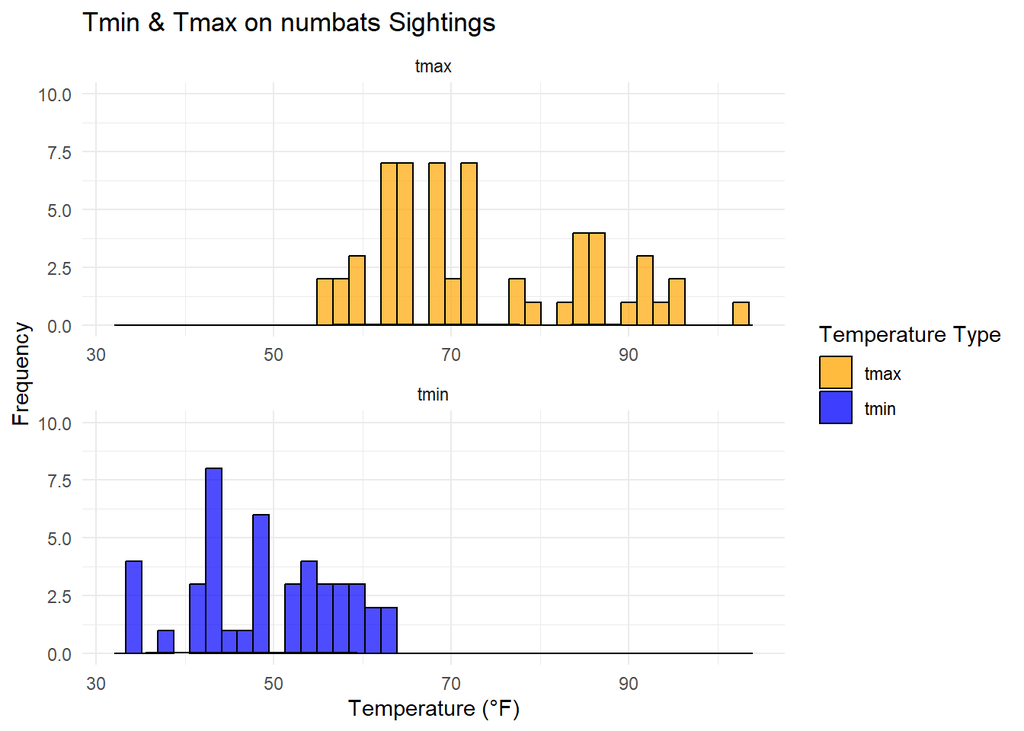

In regards to weather, the numbats have mostly been seen around 60 to 70 F in days that are the hottest. Days when it the coolest numbats are mostly seen around 40 to 50 F. This shows that numbats prefer to be in hiding during the hottest times of the day or prefer more temperate environment.

### 5.5 Wet and Sunny Days

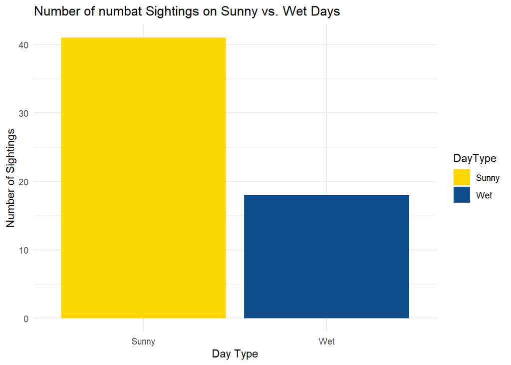

Numbats prefer sunny days compared to rainy days which correspond with the heat map above where activity increases during Australian summer months prominently November and December.

### 5.6 Most sighting in a week

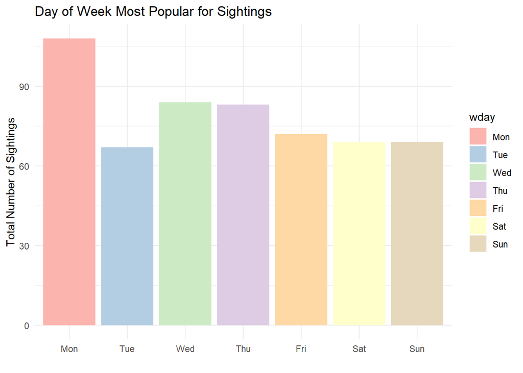

numbats are mostly seen on mondays base on the data.

# 6. Conclusion

● How could your team and business apply your insights?

Consistent and comprehensive recording of data on numbat populations can greatly enhance historical records, facilitating effective monitoring to determine whether their numbers are increasing or decreasing. Knowing the locations of numbats can assist in further development of programs that engage the public in reporting numbat sightings, enriching the data set, and aiding scientists in their research.

Monitoring numbat sightings in relations to the weather such as precipitation and temperatures allows researchers to monitor if numbats are affected by climate change and possibly help create habitats to buffer them from further effects of climate change.

Data driven polices informed by comprehensive sighting data, can support measures to safeguard numbats from habitat destruction caused by human development. Additionally, this information can assist in allocating funding towards numbat conservation efforts,to further promoting the survival and growth of their populations.

● What next steps would you or your stakeholders take based on your findings?

Given the significant number of sightings primarily in SW Australia, along with Alice Springs and Adelaide, it is recommended that future research and conservation efforts for the numbat population be concentrated in these areas. Research and study of the animal should be conducted on summer months of November and December around mid day 12:45 to 13:45 as they are most active during that time. Further study should be conducted predominantly during sunny days with temp around 60 to 70 F.

● Is there additional data you could use to expand on your findings?

The dataset under analysis exhibits a considerable volume of missing data, particularly regarding timestamp information. This issue likely arises from the involvement of numerous organizations in data collection, each potentially following different standards for what information to include in numbat sightings. To enhance the dataset’s completeness, future data gathering efforts should prioritize the inclusion of dates and times, especially considering that 30 percent of the analyzed data lacked this information. Additionally, weather data is missing in 92 percent of the cases, highlighting a critical area for improvement.There are 18 organization that contributed to the dataset sightings, only 1 organization, Earth Guardians Weekly Feed achieved 100% completeness, following close to 97% completeness iNaturalist Australia. This area has a lot of room for improvement.

# 7. Appendix

```r
knitr::opts_chunk$set(echo = FALSE)
#4.1 Library used installations:

library ("tidytuesdayR")
library("tidyverse")
library("dplyr")
library("janitor")
library("skimr")
library("lubridate")
library("ggpubr")
library("data.table")
library("viridis")
library("leaflet")
library("htmlwidgets")
library("htmltools")
library("kableExtra")
library("knitr")
library("naniar")   # Install and load naniar package for missing data analysis
library("rnoaa") #interface to NOAA (National Oceanic and Atmospheric Administration) climate and weather data.
library("galah")
library("here")
library("readr")


numbats <- readr::read_csv('https://raw.githubusercontent.com/rfordatascience/tidytuesday/master/data/2023/2023-03-07/numbats.csv')

# 4.3 Identify Column names
column_names <- names(numbats)

# Determine optimal number of columns based on total column names, ensuring more than one column if possible
total_columns <- length(column_names)
num_columns <- ifelse(total_columns > 1, min(3, total_columns), 1)  # Adjust '3' to set max columns

# Calculate number of rows, distributing names as evenly as possible across columns
rows_needed <- ceiling(total_columns / num_columns)

# Create a matrix with the appropriate structure, filling with column names
column_matrix <- matrix("", nrow = rows_needed, ncol = num_columns)  # Initialize with empty strings
column_matrix[1:total_columns] <- column_names

# Convert to data frame for kable
column_names_df <- as.data.frame(column_matrix, stringsAsFactors = FALSE)

# Adjusting the names of the data frame to exclude "Column 1", "Column 2", etc. headers
names(column_names_df) <- rep("", ncol(column_names_df))

# Use kable and kableExtra to generate and style the table without "Column 1", "Column 2", etc. as headers
kable(column_names_df, caption = "List of Column Names in the numbats Data Frame", format = "html", col.names = NA) %>%
  kable_styling(bootstrap_options = c("striped", "hover"))


# Cleanup unnecessary variables
rm(column_names, total_columns, num_columns, rows_needed, column_matrix, column_names_df)


# 4.3 make all column names text with proper formatting
clean_names(numbats)


# Rename day to YMD:
numbats$column_name <- NULL


numbats <- numbats %>% rename(YMD = day)



# 4.4 Create column data for year, month , day , week ,  y/m/d , & h:m:s  .

  # Week
numbats$week <- format(
  numbats$eventDate,
  "%W"
)

# Day
numbats$day<- format(
  numbats$eventDate,
  "%d"
)



# Time of Day, HH:MM:SS
numbats$ToD <- format(
  numbats$eventDate,
  "%H:%M:%S"
  )

# 4.5 the following checks all columns if numeric:
sapply(numbats ,is.numeric)

# Order by date
numbats<-numbats %>%
  arrange(eventDate)

#4.6  Identify outliers in the raw data.

# Convert 'ToD' from "HH:MM:SS" format to seconds past midnight
numbats$ToD_seconds <- hour(hms(numbats$ToD)) * 3600 + minute(hms(numbats$ToD)) * 60 + second(hms(numbats$ToD))

# Check the first few rows of the new column to ensure it looks correct
head(numbats$ToD_seconds)

# Simple method using the interquartile range (IQR)
Q1 <- quantile(numbats$numeric_column, 0.25)
Q3 <- quantile(numbats$numeric_column, 0.75)
IQR <- Q3 - Q1

lower_bound <- Q1 - 1.5 * IQR
upper_bound <- Q3 + 1.5 * IQR

# Results show the following outliers:
# Column: decimalLatitude - Number of outliers: 30---
# Column: decimalLongitude - Number of outliers: 0
# Column: year - Number of outliers: 14 ----shows really old years 2000 and older
# Column: hour - Number of outliers: 101 ----noting unusual
# Column: prcp - Number of outliers: 9 -----noting unusual
# Column: tmax - Number of outliers: 0
# Column: tmin - Number of outliers: 0

### there are values that are blank that needs to be converted to NA.Listing the outliers for particular column, this case decimalLatitude:

# Calculate the indices of outliers in decimalLatitude
outliers <- which(numbats$decimalLatitude < quantile(numbats$decimalLatitude, 0.25, na.rm = TRUE) - 1.5 * IQR(numbats$decimalLatitude, na.rm = TRUE) |
                    numbats$decimalLatitude > quantile(numbats$decimalLatitude, 0.75, na.rm = TRUE) + 1.5 * IQR(numbats$decimalLatitude, na.rm = TRUE))

# Save the outliers in a new dataset instead of printing them
numbat_outliers <- numbats[outliers, ]

#clean code:
rm(Q1, Q3, IQR, lower_bound, upper_bound, outliers)

#4.7 check columns to see the number of unique values.

# Initialize an empty data frame to store results
unique_values_df <- data.frame(Column_Name = character(), Number_of_Unique_Values = integer(), stringsAsFactors = FALSE)

# Iterate through each column in the numbats dataset
for (column_name in names(numbats)) {
  # Check if the column is of type character
  if (is.character(numbats[[column_name]])) {
    # Calculate the number of unique values
    num_unique_values <- length(unique(numbats[[column_name]]))
    # Append to the results data frame
    unique_values_df <- rbind(unique_values_df, data.frame(Column_Name = column_name, Number_of_Unique_Values = num_unique_values))
  }
}


# Determine the maximum number of unique values in any character column
max_length <- max(sapply(numbats, function(col) if (is.character(col)) length(unique(col)) else 0))

    # Create a list and add the counter column first
list_of_unique_vals <- list(Counter = 1:max_length)

# Iterate through each column to get unique values
for (column_name in names(numbats)) {
  if (is.character(numbats[[column_name]])) {
    # Get unique values and adjust the length by adding NAs if necessary
    unique_vals <- unique(numbats[[column_name]])
    lengthened_vals <- c(unique_vals, rep(NA, max_length - length(unique_vals)))
    list_of_unique_vals[[column_name]] <- lengthened_vals
  }
}

# table
kable(unique_values_df, "html") %>%
  kableExtra::kable_classic(full_width = F) %>%
  kable_styling(full_width = TRUE, position = "left") %>%
  column_spec(1, width = "3cm") %>%
  column_spec(2, width = "3cm")


#Results: no unusual unique values
#cleaning
rm( max_length, list_of_unique_vals)
# 4.8 Analyze patterns of missingness:
```

```r
vis_miss(numbats)

# Visualize missing data patterns
missing_percents <- sapply(numbats, function(x) mean(is.na(x))) * 100

# Create a data frame for display
missing_df <- data.frame(Column = names(missing_percents),
                         MissingPercentage = round(missing_percents, 2))

# Display as a simple table using kable
kable(missing_df, caption = "Percentage of Missing Values by Column") %>%
  kable_styling(bootstrap_options = c("striped", "hover"), full_width = F)


# results show prcp, Tmax, Min have a lot of missing data, above 90%. Data points form 600, looks like location info is present.

## Percentage of Non zero values for each column
# Initialize a data frame to store the counts and percentages
counts_df <- data.frame(Column_Name = character(),
                        Number_of_Zero_Values = integer(),
                        Number_of_NA_Values = integer(),
                        Percentage_NonZero_NonNA = numeric(),
                        stringsAsFactors = FALSE)

# Iterate through each column in the numbats data frame
for (column_name in names(numbats)) {
  total_cells <- nrow(numbats)  # Total number of cells in the column
  zero_count <- NA  # Default to NA for non-numeric columns
  na_count <- sum(is.na(numbats[[column_name]]))  # Count NA values for all columns

  # Check if the column is numeric for zero value counting
  if (is.numeric(numbats[[column_name]])) {
    zero_count <- sum(numbats[[column_name]] == 0, na.rm = TRUE)
    non_zero_non_na <- sum(!is.na(numbats[[column_name]]) & numbats[[column_name]] != 0)  # Count non-zero, non-NA
  } else {
    non_zero_non_na <- sum(!is.na(numbats[[column_name]]))  # For non-numeric, just count non-NA
  }

  # Calculate the percentage of non-zero, non-NA values
  percentage_non_zero_non_na <- (non_zero_non_na / total_cells) * 100

  # Record the counts and percentage in the counts_df data frame
  counts_df <- rbind(counts_df, data.frame(Column_Name = column_name,
                                           Number_of_Zero_Values = zero_count,
                                           Number_of_NA_Values = na_count,
                                           Percentage_NonZero_NonNA = percentage_non_zero_non_na))
}


# Calculate the percentage of non-NA values for each column grouped by dataResourceName,
# round to two decimal places, and add a column for overall row completeness also rounded to two decimal places
data_overview <- numbats %>%
  group_by(dataResourceName) %>%
  summarise(across(everything(), ~round(mean(!is.na(.)) * 100, 2))) %>%
  mutate(RowCompleteness = round(rowMeans(select(., -dataResourceName), na.rm = TRUE), 2)) %>%
  ungroup()

#------
# Select the top 10 dataResourceName entries with the highest RowCompleteness
top_completeness <- data_overview %>%
  select(dataResourceName, RowCompleteness) %>%
  arrange(desc(RowCompleteness)) %>%
  top_n(18, RowCompleteness)

# Display as a table using kable
kable(top_completeness, caption = "Data Resources by Completeness", format = "html") %>%
  kable_styling(bootstrap_options = c("striped", "hover"), full_width = F)

#cleaning
#rm(missing_percents, missing_df, counts_df, data_overview)
# 4.9 Find and clean  zero values if necessary :
#Initialize a data frame to store the counts of zero values
zero_counts_df <- data.frame(Column_Name = character(), Number_of_Zero_Values = integer(), stringsAsFactors = FALSE)

# Iterate through each column in the numbats data frame
for (column_name in names(numbats)) {
  # Check if the column is numeric
  if (is.numeric(numbats[[column_name]])) {
    # Count the number of zero values
    zero_count <- sum(numbats[[column_name]] == 0, na.rm = TRUE)

    # Record the count of zero values in the zero_counts_df data frame
    zero_counts_df <- rbind(zero_counts_df, data.frame(Column_Name = column_name, Number_of_Zero_Values = zero_count))
  }
}

kable(zero_counts_df, "html") %>%
  kableExtra::kable_classic(full_width = F) %>%
  kable_styling(full_width = TRUE, position = "left") %>%
  column_spec(1, width = "3cm") %>%
  column_spec(2, width = "3cm")

#4.10 check for leading and trailing white spaces:
# check if there is any trailing spaces in any of the column in the df

      df <- numbats

      # Initialize a vector to store the sum of flagged cells for each column
      whitespace_counts <- integer(length = ncol(df))

      # Loop through each column in the dataframe
      for (i in seq_along(df)) {
        # Check if the column is of type character
        if (is.character(df[[i]])) {
          # Flag cells with leading or trailing whitespace
          flagged_cells <- grepl("^\\s+|\\s+$", df[[i]])
          # Sum the flagged cells and store the result
          whitespace_counts[i] <- sum(flagged_cells)

          # Optionally, you can also print out the results for each column
          cat("Column:", names(df)[i], "has", whitespace_counts[i], "cells with whitespace\n")
        }
      }

      # Create a named vector with the counts of whitespace per column
      whitespace_summary <- setNames(whitespace_counts[whitespace_counts != 0], names(df)[whitespace_counts != 0])

      # Print the summary
      print(whitespace_summary)

#4.11 Check and delete duplicate rows:
# Check for duplicate rows
duplicated_rows <- duplicated(numbats)
print(duplicated_rows)

#results show none.


# 5.1 Geographic Map - location sighting

# Assuming 'numbats' is your dataset
ggplot(numbats, aes(x = decimalLongitude, y = decimalLatitude)) +
  geom_point(alpha = 0.5) + # Plot points with semi-transparency
  labs(title = "Distribution of numbat Sightings", x = "Longitude", y = "Latitude") +
  theme_minimal() + # Use a minimal theme for the plot
  annotate("rect", xmin = 115, xmax = 120, ymin = -35, ymax = -30, alpha = 0.2, color = "blue", fill = "blue") +
  annotate("rect", xmin = 130, xmax = 135, ymin = -28, ymax = -26, alpha = 0.2, color = "green", fill = "green") +
  annotate("rect", xmin = 137, xmax = 143, ymin = -35, ymax = -30, alpha = 0.2, color = "red", fill = "red") +
  annotate("text", x = 117.5, y = -29.5, label = "Closest city Perth", color = "blue") +
  annotate("text", x = 132.5, y = -25.5, label = "Closest city Alice Springs", color = "green") +
  annotate("text", x = 139.5, y = -29.5, label = "Closest city Adelaide", color = "red")
```

```r
# Step 1: Group data by location and count observations per location
numbats_geo <- numbats %>%
  group_by(decimalLatitude, decimalLongitude) %>%
  mutate(locationCount = n()) %>%
  ungroup()

# Define a function to scale the radius based on 'locationCount'
scale_radius <- function(count) {
  base_radius <- 5 # Base radius for a single observation
  ifelse(count == 1, base_radius, base_radius + sqrt(count) * 2) # Example scaling
}

# Adjust function for color mapping with vectorized operation
get_color <- function(count) {
  # Use ifelse for vectorized conditional logic
  ifelse(count == 1, "red",
         colorNumeric(palette = viridis(6, option = "D"),
                      domain = c(log1p(2), max(log1p(numbats_geo$locationCount))))(log1p(count))
  )
}

# Adjust the numbats_geo dataset for the coloring function
numbats_geo$color <- get_color(numbats_geo$locationCount)

# Create a map and set the initial view
maplocation <- leaflet(numbats_geo) %>%
  addTiles() %>%
  setView(lat = -33.3732, lng = 132.6216, zoom = 4) %>%
  addProviderTiles("Esri.WorldGrayCanvas")

# Add markers with unified style, color-coded by 'locationCount'
maplocation <- maplocation %>%
  addCircleMarkers(
    data = numbats_geo,
    lng = ~decimalLongitude,
    lat = ~decimalLatitude,
    popup = ~paste("Count:", locationCount),
    fillColor = ~color,
    fillOpacity = 0.7,
    color = "white",
    radius = ~scale_radius(locationCount),
    stroke = FALSE,
    labelOptions = labelOptions(
      style = list("font-weight" = "normal", padding = "3px 8px"),
      textsize = "13px",
      direction = "auto"
    )
  )

# Manually set colors for the legend, including gray for 1
labels <- c("1", "2", "3-5", "6-10", "11-15", "16-20", "21-25", ">25")
colors <- c("red", viridis(7, option = "D")) # Ensure there's a color for each label

maplocation <- maplocation %>%
  addLegend(
    position = "bottomright",
    title = "Observation Count",
    labels = labels,
    colors = colors,
    opacity = 1
  )

# Display the map
maplocation
# 5.2 Geographic map
# Assuming 'numbats' is already loaded and contains the necessary columns
numbats_geo <- numbats %>%
  mutate(
    eventDate = as.Date(eventDate), # Ensure eventDate is in Date format
    dateNumeric = as.numeric(eventDate), # Convert dates to numeric scale
    dateColor = ifelse(is.na(eventDate), "red", NA) # Special handling for NA dates
  )

# Define the color palette function using 'dateNumeric' for non-NA values
datePalette <- colorNumeric(
  palette = viridis(256), # Use Viridis color palette
  domain = numbats_geo$dateNumeric[!is.na(numbats_geo$dateNumeric)], # Exclude NA dates from domain
  na.color = "red" # Use red for NA dates
)

# Plot the data
maplocation <- leaflet(numbats_geo) %>%
  addTiles() %>%
  setView(lat = -33.3732, lng = 132.6216, zoom = 4) %>%
  addProviderTiles("Esri.WorldGrayCanvas")

# Split data by numbat type and create a layer for each
numbat_types <- unique(numbats_geo$scientificName)
for (type in numbat_types) {
  maplocation <- maplocation %>%
    addCircleMarkers(
      data = filter(numbats_geo, scientificName == type),
      lng = ~decimalLongitude,
      lat = ~decimalLatitude,
      popup = ~paste("Event Date:", format(eventDate, "%Y-%m-%d"), "<br>numbat Type:", scientificName),
      fillColor = ~ifelse(is.na(eventDate), "red", datePalette(dateNumeric)),
      fillOpacity = 0.7,
      color = "white",
      radius = 5,
      stroke = FALSE,
      labelOptions = labelOptions(
        style = list("font-weight" = "normal", padding = "3px 8px"),
        textsize = "13px",
        direction = "auto"
      ),
      group = type # Assign markers to a group based on numbat type
    )
}

# Add layers control to toggle numbat types
maplocation <- maplocation %>%
  addLayersControl(
    overlayGroups = numbat_types,
    options = layersControlOptions(collapsed = FALSE)
  ) %>%
  addLegend(
    position = "bottomright",
    title = "Date Spotted",
    values = ~dateNumeric,
    colors = c(viridis(5), "red"), # Example with 5 Viridis colors + red for NA
    labels = c("Early", " ", " ", " ", "Late", "NA"), # Adjust labels as needed
    opacity = 1
  )

maplocation
# table SW australia sightings
# Filter the dataset for the specified geographic range
specified_region_sightings <- numbats %>%
  filter(decimalLongitude >= 115 & decimalLongitude <= 120,
         decimalLatitude >= -35 & decimalLatitude <= -30)

# Calculate the count and percentage of sightings without dates
no_date_info <- specified_region_sightings %>%
  filter(is.na(eventDate)) %>%
  summarise(Count = n(),
            Percentage = round((n() / nrow(specified_region_sightings) * 100), 2)) %>%
  mutate(Year = "NA") # Adding Year as "NA" for consistency

# Calculate the count and percentage of sightings by year for those with dates
with_date_info <- specified_region_sightings %>%
  filter(!is.na(eventDate)) %>%
  mutate(Year = as.character(year(as.Date(eventDate)))) %>%
  group_by(Year) %>%
  summarise(Count = n(),
            Percentage = round((n() / nrow(specified_region_sightings) * 100), 2)) %>%
  select(Year, Count, Percentage)

# Combine the no-date info and with-date info into one table
combined_info <- bind_rows(with_date_info, no_date_info) %>%
  arrange(Year)

# Adjusting detailed_info for clarity in column names
detailed_info <- specified_region_sightings %>%
  filter(!is.na(eventDate)) %>%
  mutate(Year = as.character(year(as.Date(eventDate)))) %>%
  group_by(Year, scientificName) %>%
  summarise(Count = n(), .groups = 'drop') %>%
  ungroup() %>%
  complete(Year, scientificName = c("Myrmecobius fasciatus rufus", "Myrmecobius fasciatus"), fill = list(Count = 0)) %>%
  pivot_wider(names_from = scientificName, values_from = Count, values_fill = list(Count = 0)) %>%
  rename(`Myrmecobius fasciatus rufus Count` = `Myrmecobius fasciatus rufus`,
         `Myrmecobius fasciatus Count` = `Myrmecobius fasciatus`)

# Join the combined info with the detailed info
final_table <- left_join(combined_info, detailed_info, by = "Year")
```

```r
# Format and display the final table, adjusting for the new column names
final_table_formatted <- kable(final_table, caption = "SW Australia Sighting Percentages by Year and Scientific Name", format = "html") %>%
  kable_styling(full_width = TRUE, position = "left") %>%
  column_spec(1, width = "3cm") %>%
  column_spec(2, width = "3cm") %>%
  column_spec(3, width = "3cm") %>%
  kable_classic(full_width = F)

# Print the formatted table
final_table_formatted

# clean uncessary variables
rm(specified_region_sightings, no_date_info, with_date_info, combined_info, detailed_info)




# Filter the dataset for the specified geographic range in Southwest Australia
adelaide_region_sightings <- numbats %>%
  filter(decimalLongitude >= 137 & decimalLongitude <= 143,
         decimalLatitude >= -35 & decimalLatitude <= -30)

# Calculate the count and percentage of sightings without dates
no_date_sightings <- adelaide_region_sightings %>%
  filter(is.na(eventDate)) %>%
  summarise(Count = n(),
            Percentage = round((n() / nrow(adelaide_region_sightings) * 100), 2)) %>%
  mutate(Year = "NA") # Adding Year as "NA" for consistency

# Calculate the count and percentage of sightings by year for those with dates
with_date_sightings <- adelaide_region_sightings %>%
  filter(!is.na(eventDate)) %>%
  mutate(Year = as.character(year(as.Date(eventDate)))) %>%
  group_by(Year) %>%
  summarise(Count = n(),
            Percentage = round((n() / nrow(adelaide_region_sightings) * 100), 2)) %>%
  select(Year, Count, Percentage)

# Combine the no-date sightings and with-date sightings into one table
combined_sightings <- bind_rows(with_date_sightings, no_date_sightings) %>%
  arrange(Year)

# Adjusting for clarity in column names and ensuring sightings for both numbat species are reflected
species_detailed_sightings <- adelaide_region_sightings %>%
  filter(!is.na(eventDate)) %>%
  mutate(Year = as.character(year(as.Date(eventDate)))) %>%
  group_by(Year, scientificName) %>%
  summarise(Count = n(), .groups = 'drop') %>%
  ungroup() %>%
  complete(Year, scientificName = c("Myrmecobius fasciatus rufus", "Myrmecobius fasciatus"), fill = list(Count = 0)) %>%
  pivot_wider(names_from = scientificName, values_from = Count, values_fill = list(Count = 0)) %>%
  rename(`Myrmecobius fasciatus rufus Count` = `Myrmecobius fasciatus rufus`,
         `Myrmecobius fasciatus Count` = `Myrmecobius fasciatus`)

# Join the combined sightings with the species detailed sightings
adelaide_final_table <- left_join(combined_sightings, species_detailed_sightings, by = "Year")

# Format and display the final table, adjusting for the new variable names and context
adelaide_final_table_formatted <- kable(adelaide_final_table, caption = "Adelaide Region numbat Sightings Percentages by Year and Scientific Name", format = "html") %>%
  kable_styling(full_width = TRUE, position = "left") %>%
  column_spec(1, width = "3cm") %>%
  column_spec(2, width = "3cm") %>%
  column_spec(3, width = "3cm") %>%
  kable_classic(full_width = F)

# Print the formatted table
adelaide_final_table_formatted

# Clean up unnecessary variables
rm(adelaide_region_sightings, no_date_sightings, with_date_sightings, combined_sightings, species_detailed_sightings, adelaide_final_table)


# Filter the dataset for the specified geographic range in Southwest Australia
region_sightings_Central <- numbats %>%
  filter(decimalLongitude >= 130 & decimalLongitude <= 135,
         decimalLatitude >= -28 & decimalLatitude <= -26)

# Assuming 'region_sightings_alt' is your dataframe
region_center <- region_sightings_Central %>%
  # Convert NA values in 'year' column to a category (e.g., "NA")
  mutate(Year = ifelse(is.na(year), "NA", as.character(year))) %>%
  group_by(Year, scientificName) %>%
  summarise(Count = n(), .groups = 'drop')


region_center_table_formatted <- kable(region_center, caption = "Central Region numbat Sightings by Year and Scientific Name", format = "html") %>%
  kable_styling(full_width = TRUE, position = "left") %>%
  column_spec(1, width = "3cm") %>%
  column_spec(2, width = "3cm") %>%
  column_spec(3, width = "3cm") %>%
  kable_classic(full_width = F)

region_center_table_formatted

rm(region_sightings_Central, region_center)
#5.2 Heat Map


# Assuming 'numbats' is your dataset and has been loaded
heat_map_data <- numbats %>%
  filter(!is.na(week), !is.na(hour)) %>%
  mutate(
    week = as.numeric(week),
    hour = as.numeric(hour)  # Convert hour to numeric to avoid discrete to continuous scale issues
  ) %>%
  group_by(week, hour) %>%
  summarise(numtrips = n(), .groups = 'drop')

# Assuming the conversion of hour to numeric is acceptable for your analysis
heatmap_plot <- ggplot(heat_map_data, aes(x = week, y = hour, fill = numtrips)) +
  geom_tile(color = "white") +
  scale_fill_viridis_c(name = "numbat Sighting") +
  scale_y_continuous(trans = 'reverse', breaks = 0:23) +  # Use continuous scale with reverse transformation
  scale_x_continuous(
    expand = c(0, 0),
    breaks = seq(1, 52, by = 4.33),  # Approximate for simplicity
    #labels = month_labels  # Ensure this variable is defined or replace with actual labels
  ) +
  theme_light() +
  labs(title = "Heatmap of Activity", y = "Hour of the Day", x = "Week of the Year")

# Print the heatmap
print(heatmap_plot)


#5.3 Bar Graph- Time of day seen
# Convert ToD to POSIXct and cut into 15-minute intervals
numbats_bar <- numbats %>%
  mutate(
    ToD_POSIXct = as.POSIXct(ToD, format = "%H:%M:%S", tz = "UTC"),
    time_intervals = cut(ToD_POSIXct, breaks = "15 min", labels = FALSE)
  ) %>%
  filter(!is.na(time_intervals)) %>%
  group_by(time_intervals) %>%
  summarise(numtseen = n()) %>%
  ungroup()

# Generate a data frame of all possible 15-minute intervals (96 intervals for 24 hours)
all_intervals <- data.frame(time_intervals = 1:96)

# Merge the sightings data with the complete set of intervals
numbats_complete <- merge(all_intervals, numbats_bar, by = "time_intervals", all.x = TRUE)

# Fill in missing numtseen values with zero
numbats_complete$numtseen[is.na(numbats_complete$numtseen)] <- 0
```

```r
# Add time labels for plotting
numbats_complete$time_labels <- format(seq(ymd_hms("2022-01-01 00:00:00"),
                                           length.out = 96, by = "15 min"), "%H:%M")

# Determine a threshold for capping y-values and cap numtseen for visualization
threshold <- 75  # Adjust this value based on your dataset and needs
numbats_complete$plot_numtseen <- ifelse(numbats_complete$numtseen > threshold, threshold, numbats_complete$numtseen)

# Plot with capped y-values and annotate if values are capped
ggplot(numbats_complete, aes(x = as.factor(time_intervals), y = plot_numtseen)) +
  geom_bar(stat = "identity", fill = "blue") +
  geom_text(aes(label = ifelse(numtseen > threshold, 'Capped, max 400', '')),
            position = position_stack(vjust = 1), angle = 0, hjust = 0, check_overlap = TRUE, size = 2.5) +
  scale_x_discrete(labels = numbats_complete$time_labels) +
  labs(title = "Frequency of numbat Sightings",
       x = "Time of Day",
       y = "Number of Sightings (Capped)") +
  theme_minimal() +
  theme(axis.text.x = element_text(angle = 90, vjust = 0.5, hjust=0))

# Cleanup unnecessary variables
rm(numbats_bar, all_intervals, numbats_complete)

#5.4 Temperature data and sighting relationship

# Replace 'weather_data' with the name of your actual data frame
weather_data_long <- numbats %>%
    select(
      tmin,
      tmax,
      prcp
    )

# First, we need to reshape the data to  long format
weather_data_long <- weather_data_long %>%
  gather(key = "TemperatureType", value = "TemperatureValue", tmax, tmin) %>%
  # Convert temperature from Celsius to Fahrenheit
  mutate(TemperatureValue = (TemperatureValue * 9/5) + 32)

# Now create the combined histogram plot with temperatures in Fahrenheit
ggplot(weather_data_long, aes(x = TemperatureValue, fill = TemperatureType)) +
  geom_histogram(aes(y = ..count..), binwidth = 1.8, color = "black", alpha = 0.7) + # Adjusted binwidth for Fahrenheit
  geom_density(alpha = .2) +
  facet_wrap(~TemperatureType, scales = "free_x", ncol = 1) +
  scale_fill_manual(values = c("tmax" = "orange", "tmin" = "blue")) +
  labs(title = "Tmin & Tmax on numbats Sightings",
       x = "Temperature (°F)", # Updated label to Fahrenheit
       y = "Frequency",
       fill = "Temperature Type") +
  theme_minimal() +
  xlim(c(32, 104)) + # Set the x-axis limits adjusted for Fahrenheit
  ylim(0, 10) # Set the y-axis limits

# Cleanup unnecessary variable
rm(weather_data_long)

# 5.5 Wet and Sunny Day vs numbat sighting
# Filter out NA values from prcp column
numbats_filtered <- filter(numbats, !is.na(prcp))

# Categorize days as 'Sunny' or 'Wet' and count the number of rows for each category
weather_counts <- numbats_filtered %>%
  mutate(DayType = ifelse(prcp > 0, 'Wet', 'Sunny')) %>%
  group_by(DayType) %>%
  summarise(Count = n())

# Create a bar graph
ggplot(weather_counts, aes(x = DayType, y = Count, fill = DayType)) +
  geom_bar(stat = "identity") +
  labs(title = "Number of numbat Sightings on Sunny vs. Wet Days",
       x = "Day Type",
       y = "Number of Sightings") +
  scale_fill_manual(values = c('Sunny' = 'gold', 'Wet' = 'dodgerblue4')) +
  theme_minimal()


#5.6 Most sighting in a week

numbats_week <- numbats

# Convert 'wday' in 'numbats_week' to a factor with levels in the correct order
# This assumes 'wday' contains the abbreviated day names as strings
numbats_week$wday <- factor(numbats_week$wday, levels = c("Mon", "Tue", "Wed", "Thu", "Fri", "Sat", "Sun"))

# Filter out rows where 'wday' is NA and perform the aggregation in 'numbats_week'
numbats_week <- numbats_week %>%
  filter(!is.na(wday)) %>%
  group_by(wday) %>%
  summarise(numtrips = n())  # Count the number of rows for each 'wday'

# Plotting the bar graph
ggplot(numbats_week, aes(x = wday, y = numtrips, fill = wday)) +
  geom_bar(stat = "identity", position = "dodge") +
  labs(title = "Day of Week Most Popular for Sightings", y = "Total Number of Sightings", x = "") +
  theme_minimal() +
  scale_fill_brewer(palette = "Pastel1")
```